# HW-1-Final

Author

Gowri

## Step - 1

1. (30 points) Given the formulated question from the assignment description, you will now conduct EDA Checklist items 1-5. First, download 2002 and 2022 data for all sites in California from the [EPA Air Quality Data website](https://www.epa.gov/outdoor-air-quality-data/download-daily-data), then read the data into R. For each of the two datasets, check the dimensions, headers, footers, variable names and variable types. Check the distribution of the key variable we are analyzing (PM). Write up a summary of all of your findings.

   ```r
   #  Reading data
   PM25_2002 <- read.csv("Data/PM25_2002.csv")
   PM25_2022 <- read.csv("Data/PM25_2022.csv")

   # Check variable names
   names(PM25_2002)
   ```

   ```
    [1] "Date"                           "Source"
    [3] "Site.ID"                        "POC"
    [5] "Daily.Mean.PM2.5.Concentration" "Units"
    [7] "Daily.AQI.Value"                "Local.Site.Name"
    [9] "Daily.Obs.Count"                "Percent.Complete"
   [11] "AQS.Parameter.Code"             "AQS.Parameter.Description"
   [13] "Method.Code"                    "Method.Description"
   [15] "CBSA.Code"                      "CBSA.Name"
   [17] "State.FIPS.Code"                "State"
   [19] "County.FIPS.Code"               "County"
   [21] "Site.Latitude"                  "Site.Longitude"
   ```

   ```r
   names(PM25_2022)
   ```

   ```
    [1] "Date"                           "Source"
    [3] "Site.ID"                        "POC"
    [5] "Daily.Mean.PM2.5.Concentration" "Units"
    [7] "Daily.AQI.Value"                "Local.Site.Name"
    [9] "Daily.Obs.Count"                "Percent.Complete"
   [11] "AQS.Parameter.Code"             "AQS.Parameter.Description"
   [13] "Method.Code"                    "Method.Description"
   [15] "CBSA.Code"                      "CBSA.Name"
   [17] "State.FIPS.Code"                "State"
   [19] "County.FIPS.Code"               "County"
   [21] "Site.Latitude"                  "Site.Longitude"
   ```

   ```r
   # If the first column is "V1", rename it
   names(PM25_2002)[names(PM25_2002) == "V1"] <- "Date"
   names(PM25_2022)[names(PM25_2022) == "V1"] <- "Date"

   # If the first row is actually a duplicate header row, drop it
   PM25_2002 <- PM25_2002[-1, ]
   PM25_2022 <- PM25_2022[-1, ]


   #  Check dimensions
   dim(PM25_2002)
   ```

   ```
   [1] 15975    22
   ```

   ```r
   dim(PM25_2022)
   ```

   ```
   [1] 59917    22
   ```

   ```r
   #Header
   head(PM25_2002)
   ```

   ```
           Date Source  Site.ID POC Daily.Mean.PM2.5.Concentration    Units
   2 01/06/2002    AQS 60010007   1                           31.6 ug/m3 LC
   3 01/08/2002    AQS 60010007   1                           21.4 ug/m3 LC
   4 01/11/2002    AQS 60010007   1                           25.9 ug/m3 LC
   5 01/14/2002    AQS 60010007   1                           34.5 ug/m3 LC
   6 01/17/2002    AQS 60010007   1                           41.0 ug/m3 LC
   7 01/20/2002    AQS 60010007   1                           29.3 ug/m3 LC
     Daily.AQI.Value Local.Site.Name Daily.Obs.Count Percent.Complete
   2              93       Livermore               1              100
   3              74       Livermore               1              100
   4              82       Livermore               1              100
   5              98       Livermore               1              100
   6             115       Livermore               1              100
   7              89       Livermore               1              100
     AQS.Parameter.Code AQS.Parameter.Description Method.Code
   ```

   [output cut: 27 more lines]

   ```r
   head(PM25_2022)
   ```

   ```
           Date Source  Site.ID POC Daily.Mean.PM2.5.Concentration    Units
   2 01/02/2022    AQS 60010007   3                           13.9 ug/m3 LC
   3 01/03/2022    AQS 60010007   3                            7.1 ug/m3 LC
   4 01/04/2022    AQS 60010007   3                            3.7 ug/m3 LC
   5 01/05/2022    AQS 60010007   3                            4.2 ug/m3 LC
   6 01/06/2022    AQS 60010007   3                            3.8 ug/m3 LC
   7 01/07/2022    AQS 60010007   3                            2.3 ug/m3 LC
     Daily.AQI.Value Local.Site.Name Daily.Obs.Count Percent.Complete
   2              60       Livermore               1              100
   3              39       Livermore               1              100
   4              21       Livermore               1              100
   5              23       Livermore               1              100
   6              21       Livermore               1              100
   7              13       Livermore               1              100
     AQS.Parameter.Code AQS.Parameter.Description Method.Code
   ```

   [output cut: 27 more lines]

   ```r
   #Footer
   tail(PM25_2002)
   ```

   ```
               Date Source  Site.ID POC Daily.Mean.PM2.5.Concentration    Units
   15971 12/10/2002    AQS 61131003   1                             15 ug/m3 LC
   15972 12/13/2002    AQS 61131003   1                             15 ug/m3 LC
   15973 12/22/2002    AQS 61131003   1                              1 ug/m3 LC
   15974 12/25/2002    AQS 61131003   1                             23 ug/m3 LC
   15975 12/28/2002    AQS 61131003   1                              5 ug/m3 LC
   15976 12/31/2002    AQS 61131003   1                              6 ug/m3 LC
         Daily.AQI.Value      Local.Site.Name Daily.Obs.Count Percent.Complete
   15971              62 Woodland-Gibson Road               1              100
   15972              62 Woodland-Gibson Road               1              100
   15973               6 Woodland-Gibson Road               1              100
   15974              77 Woodland-Gibson Road               1              100
   15975              28 Woodland-Gibson Road               1              100
   15976              33 Woodland-Gibson Road               1              100
         AQS.Parameter.Code AQS.Parameter.Description Method.Code
   ```

   [output cut: 27 more lines]

   ```r
   tail(PM25_2022)
   ```

   ```
               Date Source  Site.ID POC Daily.Mean.PM2.5.Concentration    Units
   59913 12/01/2022    AQS 61131003   1                            3.4 ug/m3 LC
   59914 12/07/2022    AQS 61131003   1                            3.8 ug/m3 LC
   59915 12/13/2022    AQS 61131003   1                            6.0 ug/m3 LC
   59916 12/19/2022    AQS 61131003   1                           34.8 ug/m3 LC
   59917 12/25/2022    AQS 61131003   1                           23.2 ug/m3 LC
   59918 12/31/2022    AQS 61131003   1                            1.0 ug/m3 LC
         Daily.AQI.Value      Local.Site.Name Daily.Obs.Count Percent.Complete
   59913              19 Woodland-Gibson Road               1              100
   59914              21 Woodland-Gibson Road               1              100
   59915              33 Woodland-Gibson Road               1              100
   59916              99 Woodland-Gibson Road               1              100
   59917              77 Woodland-Gibson Road               1              100
   59918               6 Woodland-Gibson Road               1              100
         AQS.Parameter.Code AQS.Parameter.Description Method.Code
   ```

   [output cut: 27 more lines]

   ```r
   #Variable name
   names(PM25_2002)
   ```

   ```
    [1] "Date"                           "Source"
    [3] "Site.ID"                        "POC"
    [5] "Daily.Mean.PM2.5.Concentration" "Units"
    [7] "Daily.AQI.Value"                "Local.Site.Name"
    [9] "Daily.Obs.Count"                "Percent.Complete"
   [11] "AQS.Parameter.Code"             "AQS.Parameter.Description"
   [13] "Method.Code"                    "Method.Description"
   [15] "CBSA.Code"                      "CBSA.Name"
   [17] "State.FIPS.Code"                "State"
   [19] "County.FIPS.Code"               "County"
   [21] "Site.Latitude"                  "Site.Longitude"
   ```

   ```r
   names(PM25_2022)
   ```

   ```
    [1] "Date"                           "Source"
    [3] "Site.ID"                        "POC"
    [5] "Daily.Mean.PM2.5.Concentration" "Units"
    [7] "Daily.AQI.Value"                "Local.Site.Name"
    [9] "Daily.Obs.Count"                "Percent.Complete"
   [11] "AQS.Parameter.Code"             "AQS.Parameter.Description"
   [13] "Method.Code"                    "Method.Description"
   [15] "CBSA.Code"                      "CBSA.Name"
   [17] "State.FIPS.Code"                "State"
   [19] "County.FIPS.Code"               "County"
   [21] "Site.Latitude"                  "Site.Longitude"
   ```

   ```r
   #structure
   str(PM25_2002)
   ```

   ```
   'data.frame':   15975 obs. of  22 variables:
    $ Date                          : chr  "01/06/2002" "01/08/2002" "01/11/2002" "01/14/2002" ...
    $ Source                        : chr  "AQS" "AQS" "AQS" "AQS" ...
    $ Site.ID                       : int  60010007 60010007 60010007 60010007 60010007 60010007 60010007 60010007 60010007 60010007 ...
    $ POC                           : int  1 1 1 1 1 1 1 1 1 1 ...
    $ Daily.Mean.PM2.5.Concentration: num  31.6 21.4 25.9 34.5 41 29.3 15 18.8 37.9 37.2 ...
    $ Units                         : chr  "ug/m3 LC" "ug/m3 LC" "ug/m3 LC" "ug/m3 LC" ...
    $ Daily.AQI.Value               : int  93 74 82 98 115 89 62 69 107 105 ...
    $ Local.Site.Name               : chr  "Livermore" "Livermore" "Livermore" "Livermore" ...
    $ Daily.Obs.Count               : int  1 1 1 1 1 1 1 1 1 1 ...
    $ Percent.Complete              : num  100 100 100 100 100 100 100 100 100 100 ...
    $ AQS.Parameter.Code            : int  88101 88101 88101 88101 88101 88101 88101 88101 88101 88101 ...
    $ AQS.Parameter.Description     : chr  "PM2.5 - Local Conditions" "PM2.5 - Local Conditions" "PM2.5 - Local Conditions" "PM2.5 - Local Conditions" ...
    $ Method.Code                   : int  120 120 120 120 120 120 120 120 120 120 ...
    $ Method.Description            : chr  "Andersen RAAS2.5-300 PM2.5 SEQ w/WINS" "Andersen RAAS2.5-300 PM2.5 SEQ w/WINS" "Andersen RAAS2.5-300 PM2.5 SEQ w/WINS" "Andersen RAAS2.5-300 PM2.5 SEQ w/WINS" ...
    $ CBSA.Code                     : int  41860 41860 41860 41860 41860 41860 41860 41860 41860 41860 ...
    $ CBSA.Name                     : chr  "San Francisco-Oakland-Hayward, CA" "San Francisco-Oakland-Hayward, CA" "San Francisco-Oakland-Hayward, CA" "San Francisco-Oakland-Hayward, CA" ...
    $ State.FIPS.Code               : int  6 6 6 6 6 6 6 6 6 6 ...
    $ State                         : chr  "California" "California" "California" "California" ...
    $ County.FIPS.Code              : int  1 1 1 1 1 1 1 1 1 1 ...
    $ County                        : chr  "Alameda" "Alameda" "Alameda" "Alameda" ...
    $ Site.Latitude                 : num  37.7 37.7 37.7 37.7 37.7 ...
    $ Site.Longitude                : num  -122 -122 -122 -122 -122 ...
   ```

   ```r
   str(PM25_2022)
   ```

   ```
   'data.frame':   59917 obs. of  22 variables:
    $ Date                          : chr  "01/02/2022" "01/03/2022" "01/04/2022" "01/05/2022" ...
    $ Source                        : chr  "AQS" "AQS" "AQS" "AQS" ...
    $ Site.ID                       : int  60010007 60010007 60010007 60010007 60010007 60010007 60010007 60010007 60010007 60010007 ...
    $ POC                           : int  3 3 3 3 3 3 3 3 3 3 ...
    $ Daily.Mean.PM2.5.Concentration: num  13.9 7.1 3.7 4.2 3.8 2.3 6.9 13.6 11.2 9.2 ...
    $ Units                         : chr  "ug/m3 LC" "ug/m3 LC" "ug/m3 LC" "ug/m3 LC" ...
    $ Daily.AQI.Value               : int  60 39 21 23 21 13 38 59 55 51 ...
    $ Local.Site.Name               : chr  "Livermore" "Livermore" "Livermore" "Livermore" ...
    $ Daily.Obs.Count               : int  1 1 1 1 1 1 1 1 1 1 ...
    $ Percent.Complete              : num  100 100 100 100 100 100 100 100 100 100 ...
    $ AQS.Parameter.Code            : int  88101 88101 88101 88101 88101 88101 88101 88101 88101 88101 ...
    $ AQS.Parameter.Description     : chr  "PM2.5 - Local Conditions" "PM2.5 - Local Conditions" "PM2.5 - Local Conditions" "PM2.5 - Local Conditions" ...
    $ Method.Code                   : int  170 170 170 170 170 170 170 170 170 170 ...
    $ Method.Description            : chr  "Met One BAM-1020 Mass Monitor w/VSCC" "Met One BAM-1020 Mass Monitor w/VSCC" "Met One BAM-1020 Mass Monitor w/VSCC" "Met One BAM-1020 Mass Monitor w/VSCC" ...
    $ CBSA.Code                     : int  41860 41860 41860 41860 41860 41860 41860 41860 41860 41860 ...
    $ CBSA.Name                     : chr  "San Francisco-Oakland-Hayward, CA" "San Francisco-Oakland-Hayward, CA" "San Francisco-Oakland-Hayward, CA" "San Francisco-Oakland-Hayward, CA" ...
    $ State.FIPS.Code               : int  6 6 6 6 6 6 6 6 6 6 ...
    $ State                         : chr  "California" "California" "California" "California" ...
    $ County.FIPS.Code              : int  1 1 1 1 1 1 1 1 1 1 ...
    $ County                        : chr  "Alameda" "Alameda" "Alameda" "Alameda" ...
    $ Site.Latitude                 : num  37.7 37.7 37.7 37.7 37.7 ...
    $ Site.Longitude                : num  -122 -122 -122 -122 -122 ...
   ```

   ```r
   #summary
   summary(PM25_2002)
   ```

   ```
        Date              Source             Site.ID              POC
    Length:15975       Length:15975       Min.   :60010007   Min.   :1.000
    Class :character   Class :character   1st Qu.:60290014   1st Qu.:1.000
    Mode  :character   Mode  :character   Median :60590007   Median :1.000
                                          Mean   :60549634   Mean   :1.581
                                          3rd Qu.:60731002   3rd Qu.:1.000
                                          Max.   :61131003   Max.   :6.000

    Daily.Mean.PM2.5.Concentration    Units           Daily.AQI.Value
    Min.   :  0.00                 Length:15975       Min.   :  0.00
    1st Qu.:  7.00                 Class :character   1st Qu.: 39.00
    Median : 12.00                 Mode  :character   Median : 56.00
    Mean   : 16.12                                    Mean   : 59.28
    3rd Qu.: 20.50                                    3rd Qu.: 72.00
    Max.   :104.30                                    Max.   :185.00

    Local.Site.Name    Daily.Obs.Count Percent.Complete AQS.Parameter.Code
    Length:15975       Min.   :1       Min.   :100      Min.   :88101
    Class :character   1st Qu.:1       1st Qu.:100      1st Qu.:88101
    Mode  :character   Median :1       Median :100      Median :88101
                       Mean   :1       Mean   :100      Mean   :88215
                       3rd Qu.:1       3rd Qu.:100      3rd Qu.:88502
                       Max.   :1       Max.   :100      Max.   :88502

    AQS.Parameter.Description  Method.Code    Method.Description   CBSA.Code
    Length:15975              Min.   :117.0   Length:15975       Min.   :12540
    Class :character          1st Qu.:120.0   Class :character   1st Qu.:23420
    Mode  :character          Median :120.0   Mode  :character   Median :40140
                              Mean   :297.1                      Mean   :33269
                              3rd Qu.:707.0                      3rd Qu.:41740
                              Max.   :810.0                      Max.   :49700
                                                                 NA's   :929
     CBSA.Name         State.FIPS.Code    State           County.FIPS.Code
    Length:15975       Min.   :6       Length:15975       Min.   :  1.00
    Class :character   1st Qu.:6       Class :character   1st Qu.: 29.00
    Mode  :character   Median :6       Mode  :character   Median : 59.00
                       Mean   :6                          Mean   : 54.78
                       3rd Qu.:6                          3rd Qu.: 73.00
                       Max.   :6                          Max.   :113.00

       County          Site.Latitude   Site.Longitude
    Length:15975       Min.   :32.63   Min.   :-124.2
    Class :character   1st Qu.:34.07   1st Qu.:-121.4
    Mode  :character   Median :35.36   Median :-119.1
                       Mean   :36.00   Mean   :-119.4
                       3rd Qu.:37.77   3rd Qu.:-117.9
                       Max.   :41.71   Max.   :-115.5
   ```

   ```r
   summary(PM25_2022)
   ```

   ```
        Date              Source             Site.ID              POC
    Length:59917       Length:59917       Min.   :60010007   Min.   : 1.000
    Class :character   Class :character   1st Qu.:60290019   1st Qu.: 1.000
    Mode  :character   Mode  :character   Median :60631006   Median : 3.000
                                          Mean   :60564234   Mean   : 3.768
                                          3rd Qu.:60731026   3rd Qu.: 3.000
                                          Max.   :61131003   Max.   :24.000

    Daily.Mean.PM2.5.Concentration    Units           Daily.AQI.Value
    Min.   : -6.700                Length:59917       Min.   :  0.00
    1st Qu.:  4.100                Class :character   1st Qu.: 23.00
    Median :  6.800                Mode  :character   Median : 38.00
    Mean   :  8.414                                   Mean   : 39.22
    3rd Qu.: 10.700                                   3rd Qu.: 54.00
    Max.   :302.500                                   Max.   :454.00

    Local.Site.Name    Daily.Obs.Count Percent.Complete AQS.Parameter.Code
    Length:59917       Min.   :1       Min.   :100      Min.   :88101
    Class :character   1st Qu.:1       1st Qu.:100      1st Qu.:88101
    Mode  :character   Median :1       Median :100      Median :88101
                       Mean   :1       Mean   :100      Mean   :88192
                       3rd Qu.:1       3rd Qu.:100      3rd Qu.:88101
                       Max.   :1       Max.   :100      Max.   :88502

    AQS.Parameter.Description  Method.Code  Method.Description   CBSA.Code
    Length:59917              Min.   :143   Length:59917       Min.   :12540
    Class :character          1st Qu.:170   Class :character   1st Qu.:31080
    Mode  :character          Median :170   Mode  :character   Median :40140
                              Mean   :338                      Mean   :34971
                              3rd Qu.:707                      3rd Qu.:41860
                              Max.   :810                      Max.   :49700
                                                               NA's   :4569
     CBSA.Name         State.FIPS.Code    State           County.FIPS.Code
    Length:59917       Min.   :6       Length:59917       Min.   :  1.00
    Class :character   1st Qu.:6       Class :character   1st Qu.: 29.00
    Mode  :character   Median :6       Mode  :character   Median : 63.00
                       Mean   :6                          Mean   : 56.28
                       3rd Qu.:6                          3rd Qu.: 73.00
                       Max.   :6                          Max.   :113.00

       County          Site.Latitude   Site.Longitude
    Length:59917       Min.   :32.58   Min.   :-124.2
    Class :character   1st Qu.:34.07   1st Qu.:-121.4
    Mode  :character   Median :36.49   Median :-119.6
                       Mean   :36.25   Mean   :-119.6
                       3rd Qu.:37.96   3rd Qu.:-117.9
                       Max.   :41.76   Max.   :-115.5
   ```

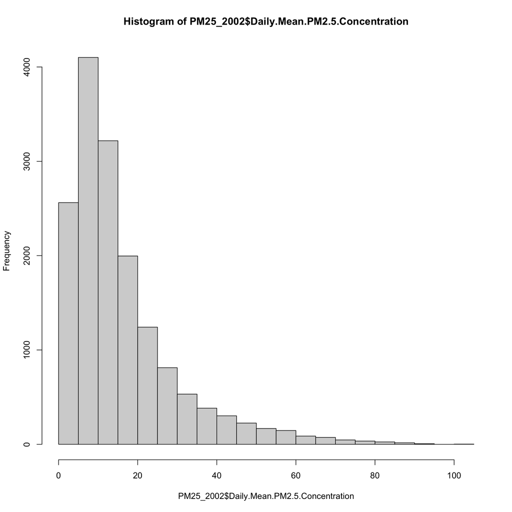

   ```r
   #  Make key variable numeric as it is being considered as charachter
   PM25_2002$Daily.Mean.PM2.5.Concentration <-
     as.numeric(PM25_2002$Daily.Mean.PM2.5.Concentration)

   PM25_2022$Daily.Mean.PM2.5.Concentration <-
     as.numeric(PM25_2022$Daily.Mean.PM2.5.Concentration)

   #Distribution - Histogram
   hist(PM25_2002$Daily.Mean.PM2.5.Concentration)
   ```

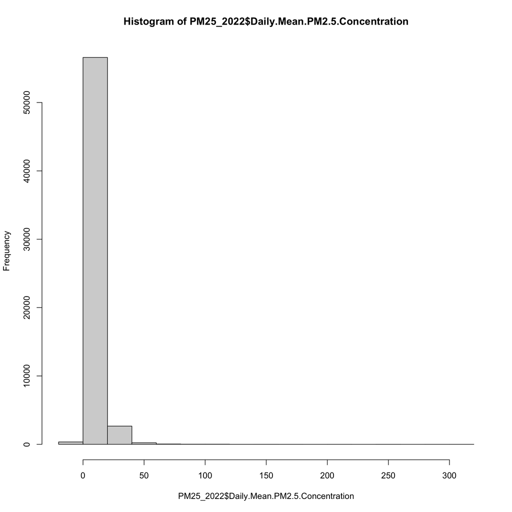

   ```r
   hist(PM25_2022$Daily.Mean.PM2.5.Concentration)
   ```

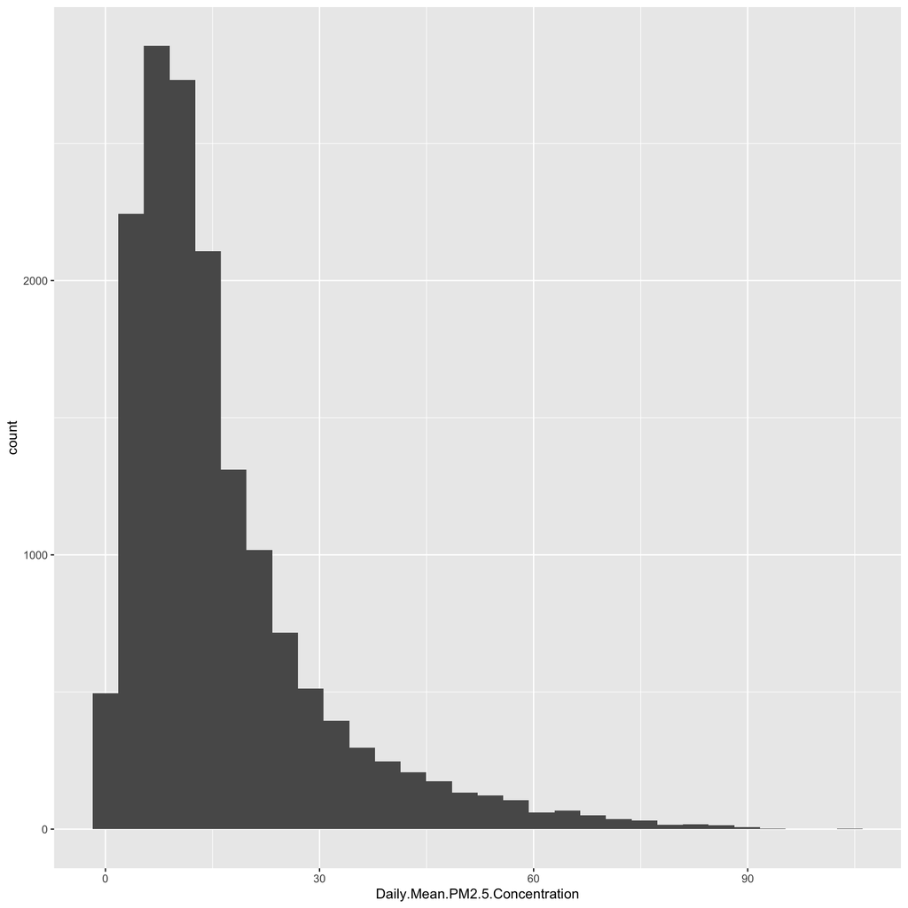

   ```r
   # Distribution -  ggplot histograms & densities

   library(tidyverse)
   ggplot(PM25_2002, aes(x = Daily.Mean.PM2.5.Concentration)) +
     geom_histogram(bins = 30)
   ```

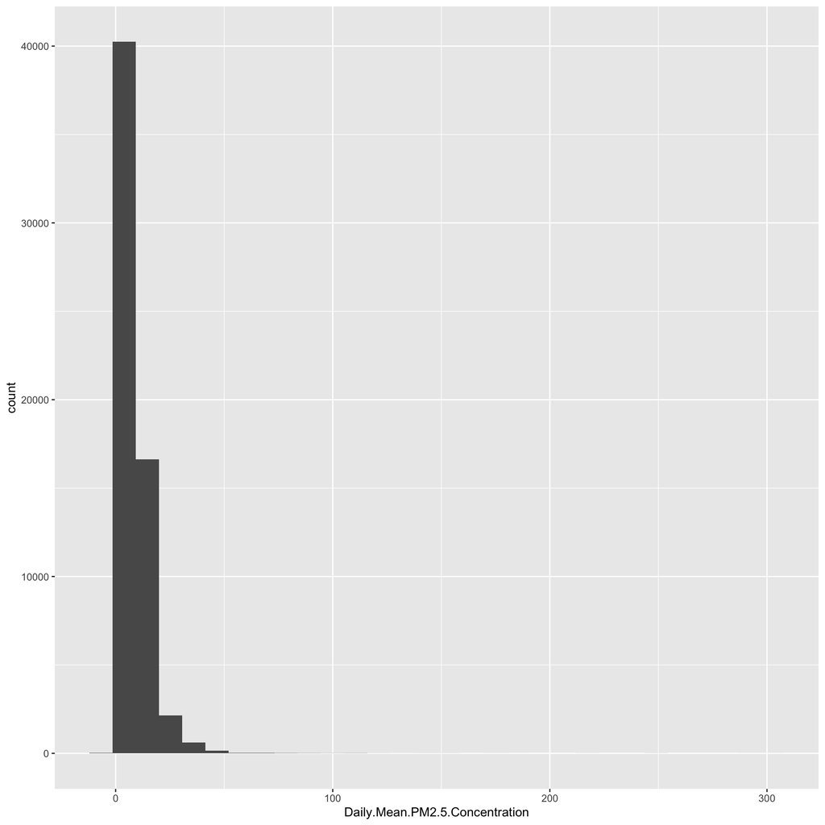

   ```r
   ggplot(PM25_2022, aes(x = Daily.Mean.PM2.5.Concentration)) +
     geom_histogram(bins = 30)
   ```

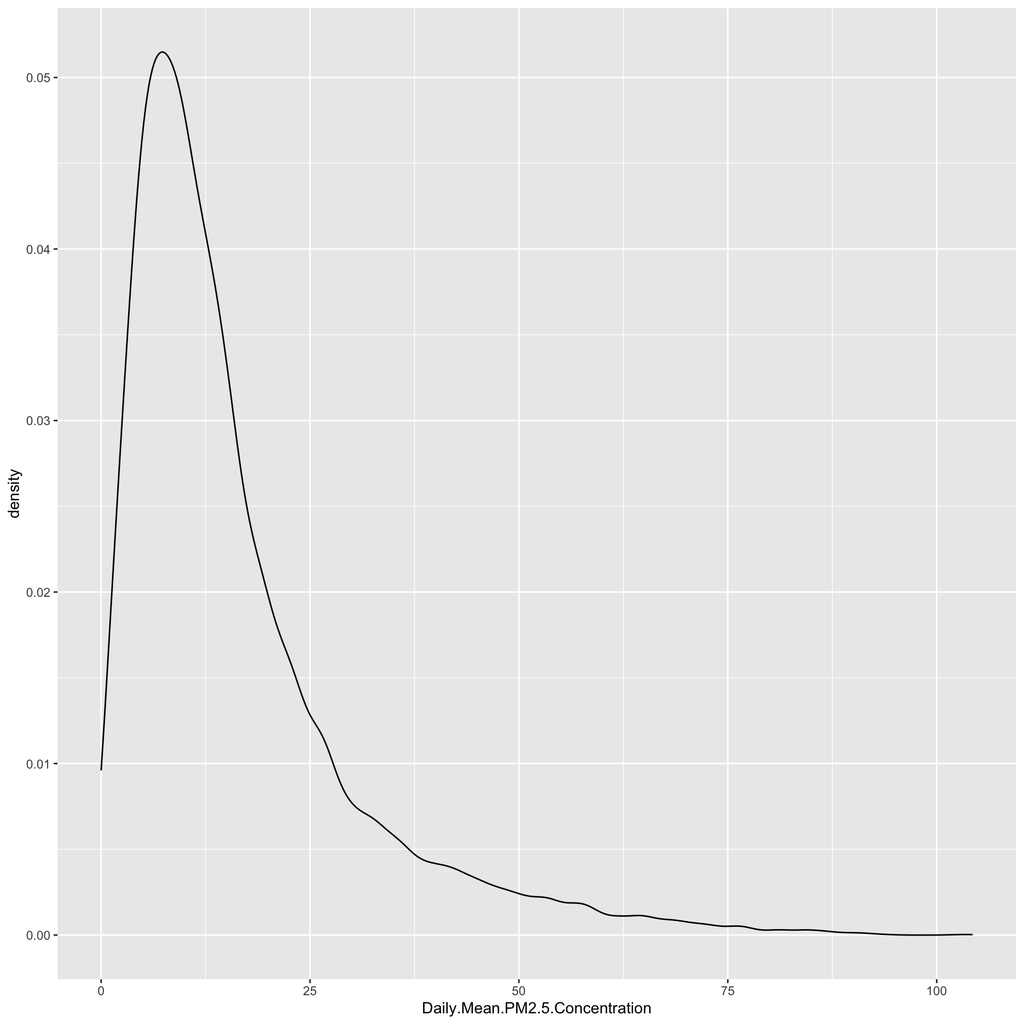

   ```r
   ggplot(PM25_2002, aes(x = Daily.Mean.PM2.5.Concentration)) +
     geom_density()
   ```

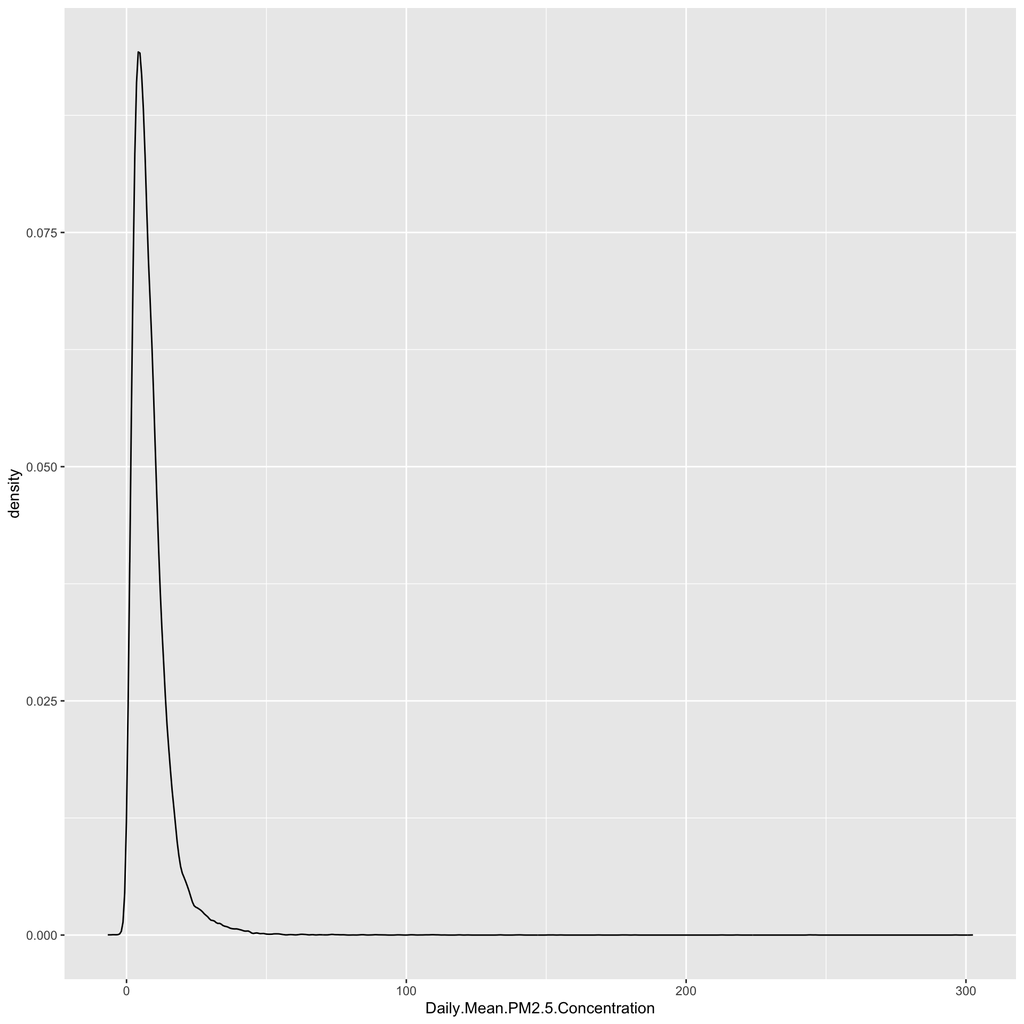

   ```r
   ggplot(PM25_2022, aes(x = Daily.Mean.PM2.5.Concentration)) +
     geom_density()
   ```

**Summary 1 -**

Summary for PM2.5 showed that in 2002, values ranged from 0.00 to 104.30 µg/m³, with a median of about 12.00 µg/m³. In contrast, 2022 values ranged from –6.70 to 302.50 µg/m³, with a median of median of 6.80 µg/m³. These values suggest that concentrations of particles have decreased over the 20-year period.

## Step - 2

2. (10 points) Combine the two years of data into one data frame. Use the `Date` variable to create a new column for year, which will serve as an identifier. Change the names of the key variables so that they are easier to refer to in your code.

```r
library(tidyverse)
library(lubridate)

# Checkig the name of the column
names(PM25_2002)
```

```
 [1] "Date"                           "Source"
 [3] "Site.ID"                        "POC"
 [5] "Daily.Mean.PM2.5.Concentration" "Units"
 [7] "Daily.AQI.Value"                "Local.Site.Name"
 [9] "Daily.Obs.Count"                "Percent.Complete"
[11] "AQS.Parameter.Code"             "AQS.Parameter.Description"
[13] "Method.Code"                    "Method.Description"
[15] "CBSA.Code"                      "CBSA.Name"
[17] "State.FIPS.Code"                "State"
[19] "County.FIPS.Code"               "County"
[21] "Site.Latitude"                  "Site.Longitude"
```

```r
names(PM25_2022)
```

```
 [1] "Date"                           "Source"
 [3] "Site.ID"                        "POC"
 [5] "Daily.Mean.PM2.5.Concentration" "Units"
 [7] "Daily.AQI.Value"                "Local.Site.Name"
 [9] "Daily.Obs.Count"                "Percent.Complete"
[11] "AQS.Parameter.Code"             "AQS.Parameter.Description"
[13] "Method.Code"                    "Method.Description"
[15] "CBSA.Code"                      "CBSA.Name"
[17] "State.FIPS.Code"                "State"
[19] "County.FIPS.Code"               "County"
[21] "Site.Latitude"                  "Site.Longitude"
```

```r
library(lubridate)

PM25_2002 <- PM25_2002 %>%
  mutate(Date = mdy(Date),
         year = year(Date))

PM25_2022 <- PM25_2022 %>%
  mutate(Date = mdy(Date),
         year = year(Date))

#Changing the name of the variables
PM25_2002 <- PM25_2002 %>%
  rename(pm25     = Daily.Mean.PM2.5.Concentration,
         Site     = Site.ID,
         SiteName = Local.Site.Name,
         Latitude = Site.Latitude,
         Longitude= Site.Longitude)

PM25_2022 <- PM25_2022 %>%
  rename(pm25     = Daily.Mean.PM2.5.Concentration,
         Site     = Site.ID,
         SiteName = Local.Site.Name,
         Latitude = Site.Latitude,
         Longitude= Site.Longitude)


# PM25 should be read as numeric
PM25_2002 <- PM25_2002 %>% mutate(pm25 = as.numeric(pm25))
PM25_2022 <- PM25_2022 %>% mutate(pm25 = as.numeric(pm25))

# Combining data
PM25_all <- bind_rows(PM25_2002, PM25_2022)

# Checking the dimensions
dim(PM25_all)
```

```
[1] 75892    23
```

```r
names(PM25_all)
```

```
 [1] "Date"                      "Source"
 [3] "Site"                      "POC"
 [5] "pm25"                      "Units"
 [7] "Daily.AQI.Value"           "SiteName"
 [9] "Daily.Obs.Count"           "Percent.Complete"
[11] "AQS.Parameter.Code"        "AQS.Parameter.Description"
[13] "Method.Code"               "Method.Description"
[15] "CBSA.Code"                 "CBSA.Name"
[17] "State.FIPS.Code"           "State"
[19] "County.FIPS.Code"          "County"
[21] "Latitude"                  "Longitude"
[23] "year"
```

```r
head(PM25_all)
```

```
        Date Source     Site POC pm25    Units Daily.AQI.Value  SiteName
1 2002-01-06    AQS 60010007   1 31.6 ug/m3 LC              93 Livermore
2 2002-01-08    AQS 60010007   1 21.4 ug/m3 LC              74 Livermore
3 2002-01-11    AQS 60010007   1 25.9 ug/m3 LC              82 Livermore
4 2002-01-14    AQS 60010007   1 34.5 ug/m3 LC              98 Livermore
5 2002-01-17    AQS 60010007   1 41.0 ug/m3 LC             115 Livermore
6 2002-01-20    AQS 60010007   1 29.3 ug/m3 LC              89 Livermore
  Daily.Obs.Count Percent.Complete AQS.Parameter.Code AQS.Parameter.Description
1               1              100              88101  PM2.5 - Local Conditions
2               1              100              88101  PM2.5 - Local Conditions
3               1              100              88101  PM2.5 - Local Conditions
4               1              100              88101  PM2.5 - Local Conditions
5               1              100              88101  PM2.5 - Local Conditions
6               1              100              88101  PM2.5 - Local Conditions
  Method.Code                    Method.Description CBSA.Code
```

[output cut: 20 more lines]

```r
tail(PM25_all)
```

```
            Date Source     Site POC pm25    Units Daily.AQI.Value
75887 2022-12-01    AQS 61131003   1  3.4 ug/m3 LC              19
75888 2022-12-07    AQS 61131003   1  3.8 ug/m3 LC              21
75889 2022-12-13    AQS 61131003   1  6.0 ug/m3 LC              33
75890 2022-12-19    AQS 61131003   1 34.8 ug/m3 LC              99
75891 2022-12-25    AQS 61131003   1 23.2 ug/m3 LC              77
75892 2022-12-31    AQS 61131003   1  1.0 ug/m3 LC               6
                  SiteName Daily.Obs.Count Percent.Complete AQS.Parameter.Code
75887 Woodland-Gibson Road               1              100              88101
75888 Woodland-Gibson Road               1              100              88101
75889 Woodland-Gibson Road               1              100              88101
75890 Woodland-Gibson Road               1              100              88101
75891 Woodland-Gibson Road               1              100              88101
75892 Woodland-Gibson Road               1              100              88101
      AQS.Parameter.Description Method.Code
```

[output cut: 27 more lines]

```r
table(PM25_all$year, useNA = "ifany")
```

```
 2002  2022
15975 59917
```

```r
nrow(PM25_2002) + nrow(PM25_2022); nrow(PM25_all)
```

```
[1] 75892
```

```
[1] 75892
```

```r
PM25_all %>%
  select(Date, year, pm25, Site, SiteName, Latitude, Longitude) %>%
  arrange(year, Date) %>%
  head(12)
```

```
         Date year pm25     Site                      SiteName Latitude
1  2002-01-01 2002 10.6 60074001     TRAFFIC, RURAL PAVED ROAD 39.32756
2  2002-01-01 2002 20.9 60130002                       Concord 37.93601
3  2002-01-01 2002 26.1 60290014        Bakersfield-California 35.35661
4  2002-01-01 2002 30.3 60290014        Bakersfield-California 35.35661
5  2002-01-01 2002 31.1 60290014        Bakersfield-California 35.35661
6  2002-01-01 2002 32.3 60370002                         Azusa 34.13650
7  2002-01-01 2002 39.6 60371103 Los Angeles-North Main Street 34.06659
8  2002-01-01 2002 47.1 60374002            Long Beach (North) 33.82376
9  2002-01-01 2002 47.9 60590007                       Anaheim 33.83062
10 2002-01-01 2002 66.3 60658001                      Rubidoux 33.99958
11 2002-01-01 2002 17.0 60670010      Sacramento-1309 T Street 38.56844
12 2002-01-01 2002 39.3 60730003                      El Cajon 32.79119
   Longitude
1  -121.6688
2  -122.0262
3  -119.0626
4  -119.0626
5  -119.0626
6  -117.9239
7  -118.2269
8  -118.1892
9  -117.9385
10 -117.4160
11 -121.4931
12 -116.9421
```

```r
sapply(PM25_all[c("Date","year","pm25")], class)
```

```
     Date      year      pm25
   "Date" "numeric" "numeric"
```

```r
summary(PM25_all$pm25)
```

```
   Min. 1st Qu.  Median    Mean 3rd Qu.    Max.
  -6.70    4.40    7.60   10.04   12.20  302.50
```

```r
unique(PM25_all$year)
```

```
[1] 2002 2022
```

**Summary-**

### Step - 3

3. (20 points) Create a basic map (or maps) in either `leaflet` or `ggplot` showing the locations of the monitoring sites, using different colors for each year. Summarize the spatial distribution of the sites. Does this distribution change from 2002 to 2022?

```r
library(tidyverse)
library(leaflet)

# collapse daily rows → one row per site–year
sites <- PM25_all %>%
  select(year, County, Latitude, Longitude) %>%
  mutate(
    Latitude  = as.numeric(Latitude),
    Longitude = as.numeric(Longitude)
  ) %>%
  filter(!is.na(Latitude), !is.na(Longitude)) %>%
  count(County, Latitude, Longitude, year, name = "n_days")   # class/lab style

# palette for numeric years
year_pal <- colorNumeric(c("red","blue"), domain = c(2002, 2022))

leaflet(sites) %>%
  addProviderTiles("OpenStreetMap") %>%
  addCircles(lat=~Latitude, lng=~Longitude, color=~year_pal(year),
             opacity=1, fillOpacity=1, radius=500) %>%
  addLegend("bottomleft",
            colors = c(year_pal(2002), year_pal(2022)),
            labels = c("2002","2022"),
            title = "Year", opacity = 1)
```

[interactive chart not shown]

**Summary -**

The maps show that monitoring sites are spread across California, with many around major areas such as the Bay Area, Los Angeles, and the Central Valley. The total number of sites increased from 2002 to 2022 (15,976 rows vs. 59,918 rows in the raw datasets). This increase possibly the addition of new monitoring sites in certain counties.

Overall, geographic coverage was similar even though the number of monitoring sites increased in 2022.

## Step - 4

4. (10 points) Check for any data issues such as missing or implausible values of PM in the combined dataset. Calculate the proportion of missing/implausible values for each year and report any temporal patterns you see in these observations.

```r
#  Reading data
PM25_2002 <- read.csv("Data/PM25_2002.csv")
PM25_2022 <- read.csv("Data/PM25_2022.csv")

#summary of pm25
summary(PM25_all$pm25)
```

```
   Min. 1st Qu.  Median    Mean 3rd Qu.    Max.
  -6.70    4.40    7.60   10.04   12.20  302.50
```

```r
# Missing values by year
table(PM25_all$year, is.na(PM25_all$pm25))
```

```
       FALSE
  2002 15975
  2022 59917
```

```r
# Proportion of missing/ implausible data for 2002
sum(PM25_all$year == 2002 & is.na(PM25_all$pm25)) / sum(PM25_all$year == 2002)
```

```
[1] 0
```

```r
# Proportion of missing/implausible values  for 2022
sum(PM25_all$year == 2022 & is.na(PM25_all$pm25)) / sum(PM25_all$year == 2022)
```

```
[1] 0
```

```r
# Implausible values are values which are pm25 < 0 OR pm25 > 500
table(PM25_all$year, PM25_all$pm25 < 0 | PM25_all$pm25 > 500)
```

```
       FALSE  TRUE
  2002 15975     0
  2022 59702   215
```

```r
# Proportion of implausible values for 2002
sum(PM25_all$year == 2002 & (PM25_all$pm25 < 0 | PM25_all$pm25 > 500)) / sum(PM25_all$year == 2002)
```

```
[1] 0
```

```r
# Proportion of implausible data  for 2022
sum(PM25_all$year == 2022 & (PM25_all$pm25 < 0 | PM25_all$pm25 > 500)) / sum(PM25_all$year == 2022)
```

```
[1] 0.003588297
```

```r
#  count negatives separately
table(PM25_all$year, PM25_all$pm25 < 0)
```

```
       FALSE  TRUE
  2002 15975     0
  2022 59702   215
```

## Step - 5

1. (30 points) Explore the main question of interest at three different levels of spatial resolution. Create data visualizations (e.g. boxplots, histograms, line plots, violin plots) **and** summary statistics that best suit each level of the analysis. Be sure to write up explanations of what you observe at each level.
- Level 1: State. Examine the primary question for the entire state.
- Level 2: County. Examine the primary question for every county in California.
- Level 3: City. Restrict the data to sites in Los Angeles county and examine the primary question for every site.

```r
# 5.1 - LEVEL 1 - STATE

# Libraries
library(tidyverse)
library(data.table)
library(lubridate)

#  Reading data
PM25_2002 <- read.csv("Data/PM25_2002.csv")
PM25_2022 <- read.csv("Data/PM25_2022.csv")

#  Combine 2002 + 2022

PM25_2002$year <- 2002
PM25_2022$year <- 2022

PM_state <- rbind(PM25_2002, PM25_2022)

#  Keeping the needed columns only and renaming them

names(PM_state)[names(PM_state) == "Daily.Mean.PM2.5.Concentration"] <- "pm"
names(PM_state)[names(PM_state) == "Date"] <- "date"

# emiving implausible data
PM_state <- PM_state %>% filter(pm >= 0)

# summary statistics by the year
PM_state %>%
  summarize(
    n = n(),
    mean = mean(pm, na.rm = TRUE),
    sd = sd(pm, na.rm = TRUE),
    median = median(pm, na.rm = TRUE),
    q25 = quantile(pm, 0.25, na.rm = TRUE),
    q75 = quantile(pm, 0.75, na.rm = TRUE),
    .by = year
  )
```

```
  year     n      mean        sd median q25  q75
1 2002 15976 16.115943 13.867372   12.0 7.0 20.5
2 2022 59703  8.447244  7.631906    6.8 4.1 10.7
```

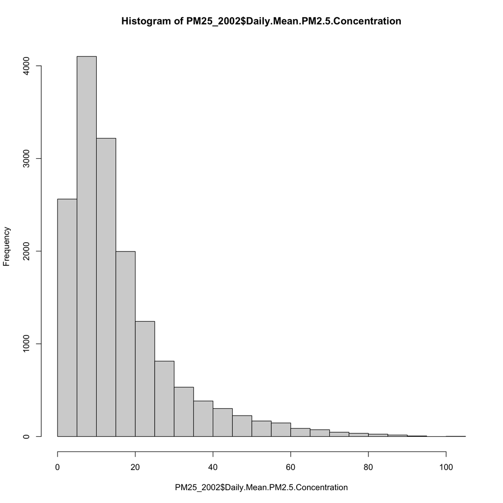

```r
# Data visualization
# Histogram for 2002
hist(PM25_2002$Daily.Mean.PM2.5.Concentration)
```

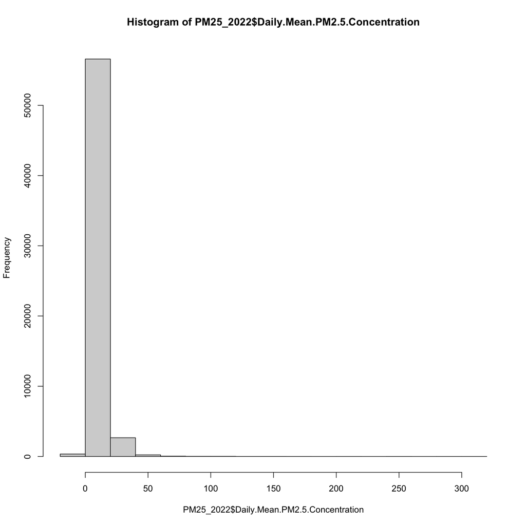

```r
# Histogram for 2022
hist(PM25_2022$Daily.Mean.PM2.5.Concentration)
```

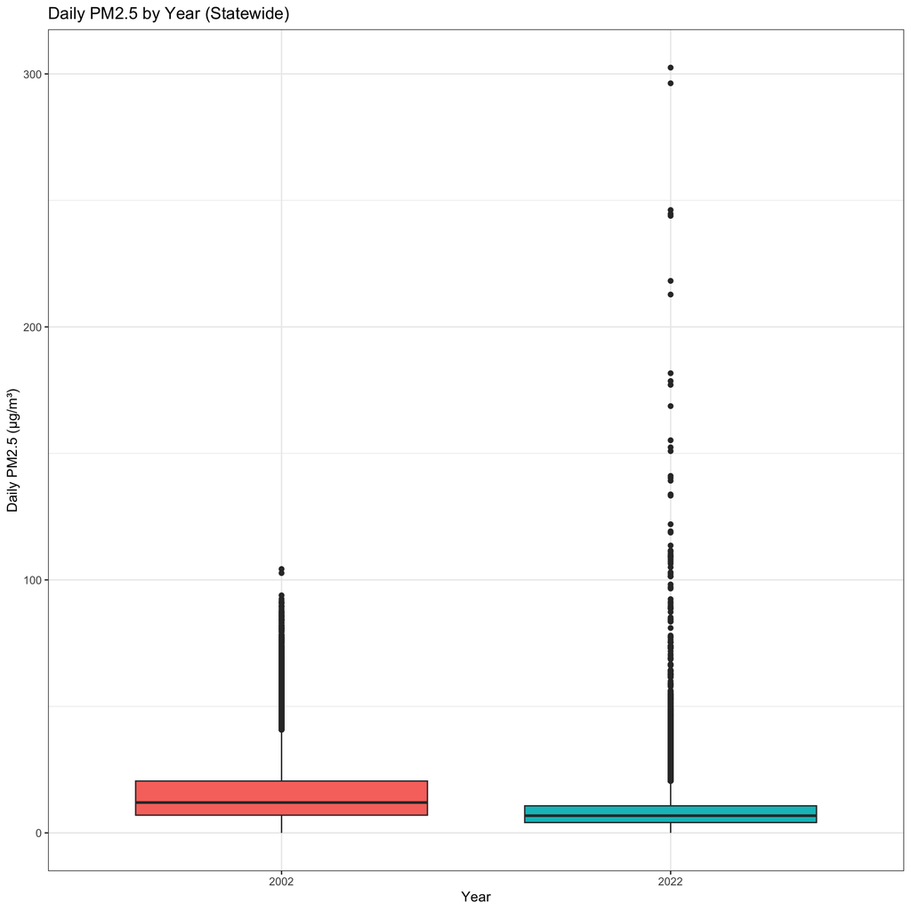

```r
#  Boxplot by year
ggplot(PM_state, aes(x = factor(year), y = pm, fill = factor(year))) +
  geom_boxplot() +
  labs(title = "Daily PM2.5 by Year (Statewide)",
       x = "Year", y = "Daily PM2.5 (µg/m³)") +
  theme_bw() +
  theme(legend.position = "none")
```

**EXPLANATION-**

Across the state, PM2.5 concentrations decreased between 2002 and 2022. In 2002, the mean daily concentration was 16.1 µg/m³ with a median of 12.0 µg/m³, while in 2022 the mean dropped to 8.4 µg/m³ and the median to 6.8 µg/m³. The histograms and boxplots further show that 2002 had a wider spread, whereas in 2022 the distribution was tighter. These results indicate an improvement in air quality over the 20-year period.

```r
#5.2- LEVEL 2 - COUNTY

library(tidyverse)

names(PM_state)[names(PM_state) == "Daily.Mean.PM2.5.Concentration"] <- "pm"
names(PM_state)[names(PM_state) == "Date"] <- "date"

# excluding implausible data
PM_state <- PM_state %>% filter(pm >= 0)

#summary statistics table
county_year_summ <- PM_state %>%
  summarize(
    n      = n(),
    mean   = mean(pm, na.rm = TRUE),
    sd     = sd(pm, na.rm = TRUE),
    median = median(pm, na.rm = TRUE),
    q25    = quantile(pm, 0.25, na.rm = TRUE),
    q75    = quantile(pm, 0.75, na.rm = TRUE),
    .by = c(County, year)
  )
county_year_summ
```

```
            County year    n      mean        sd median    q25    q75
1          Alameda 2002  201 14.252736 11.434627  10.00  6.700 16.900
2            Butte 2002  473 14.761311 11.664340  11.50  7.300 17.800
3        Calaveras 2002   60  9.900000  6.495631   8.00  6.000 12.250
4           Colusa 2002   95 11.726316 10.005788   9.00  5.000 14.500
5     Contra Costa 2002  276 15.087319 14.473492   9.50  6.500 16.625
6        Del Norte 2002  110  3.815455  2.557995   3.45  1.900  5.650
7        El Dorado 2002  208  4.914423  4.073501   3.95  2.000  7.000
8           Fresno 2002  760 19.929605 18.910539  12.95  7.500 24.000
9         Humboldt 2002   59  7.794915  4.585751   6.80  5.000  9.250
10        Imperial 2002  342 12.709649  7.703234  11.10  7.925 15.000
11            Inyo 2002  277  7.141516 10.487479   4.00  2.700  7.000
12            Kern 2002 1800 23.001222 18.718499  16.50 10.100 29.800
13           Kings 2002   83 24.695181 19.058606  18.00 10.100 31.950
14            Lake 2002   61  6.503279 10.879445   4.00  2.700  6.000
```

[output cut: 84 more lines]

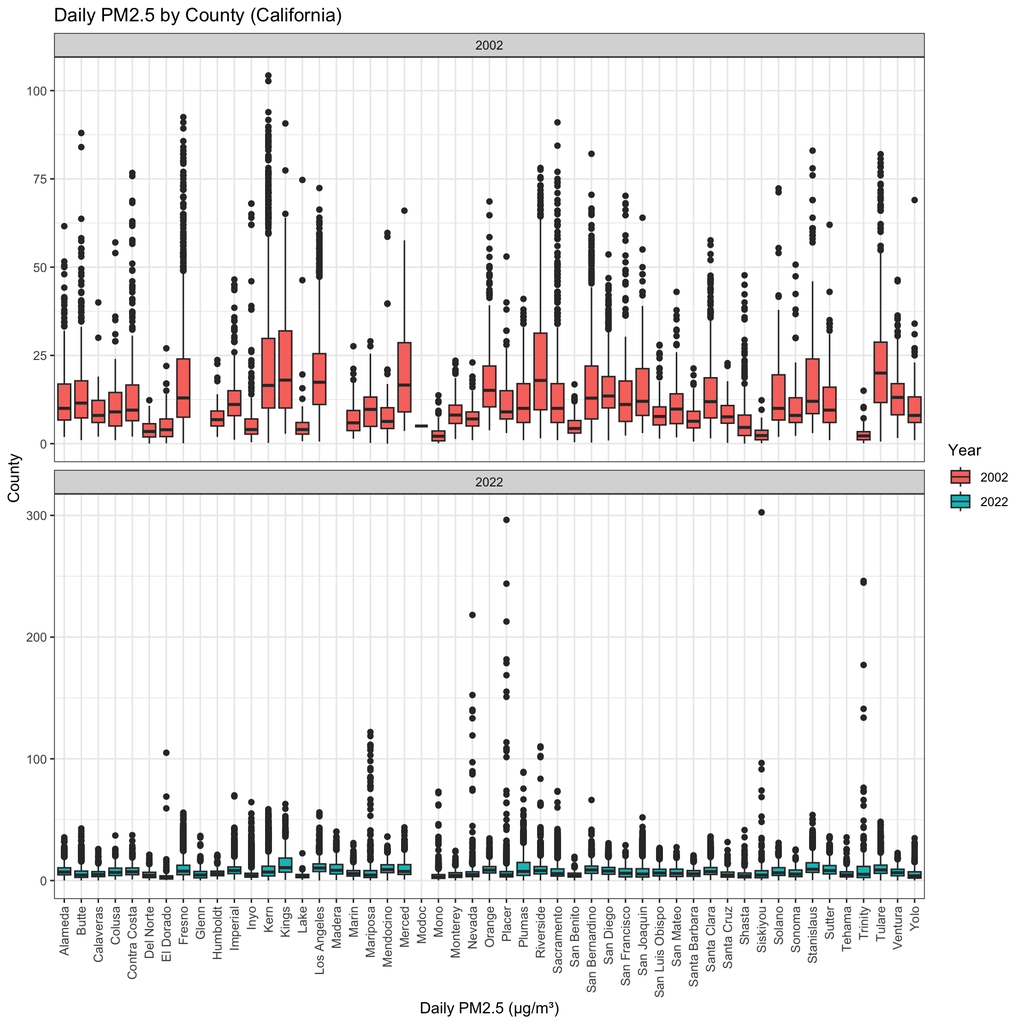

```r
ggplot(PM_state, aes(x = County, y = pm, fill = factor(year))) +
  geom_boxplot() +
  facet_wrap(~ year, ncol = 1, scales = "free_y") +
  labs(title = "Daily PM2.5 by County (California)",
       x = "Daily PM2.5 (µg/m³)", y = "County", fill = "Year") +
  theme_bw() +
  theme(axis.text.x = element_text(angle = 90, vjust = 0.5, hjust = 1))
```

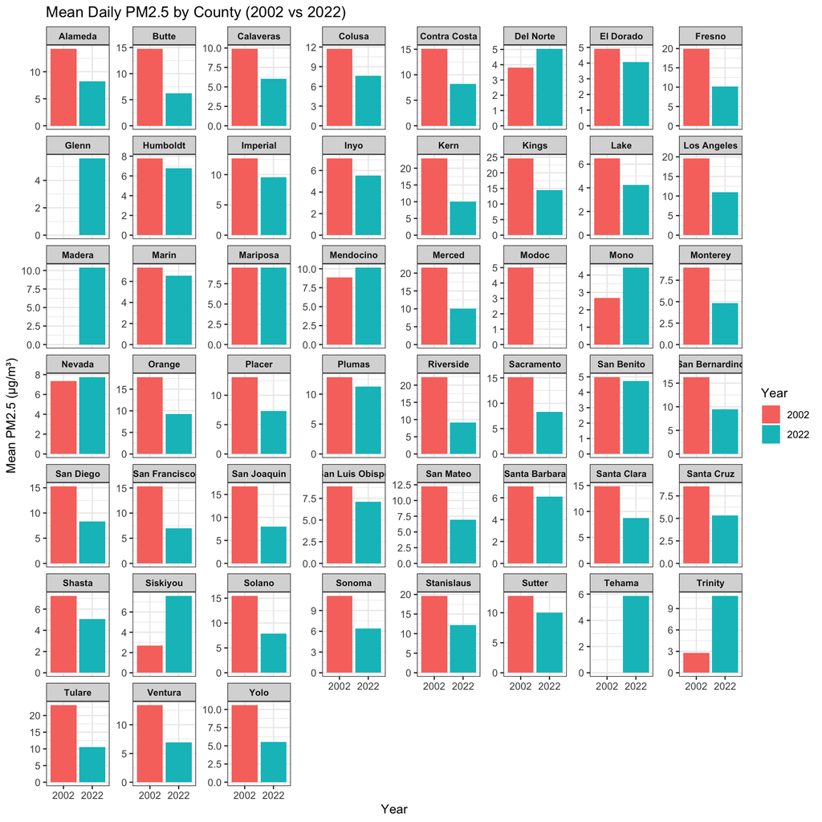

```r
# Calculating means
county_means <- PM_state %>%
  summarize(pm_mean = mean(pm, na.rm = TRUE), .by = c(County, year))

# Bar plot
# Base R: make a simple group from the first letter of County
county_means$Group <- substring(as.character(county_means$County), 1, 1)

# 2002


# --- Bar plot for 2022 ---
# Make sure year is factor for clear labels
county_means$year <- factor(county_means$year)

# Faceted barplot
ggplot(county_means, aes(x = year, y = pm_mean, fill = year)) +
  geom_col(position = "dodge") +
  facet_wrap(~ County, scales = "free_y") +
  labs(title = "Mean Daily PM2.5 by County (2002 vs 2022)",
       x = "Year", y = "Mean PM2.5 (µg/m³)", fill = "Year") +
  theme_bw() +
  theme(strip.text = element_text(size = 8, face = "bold"))
```

```r
#5.3- LEVEL 3 - CITY


# Combine 2002 + 2022
PM25_2002$year <- 2002
PM25_2022$year <- 2022
pm_all <- rbind(PM25_2002, PM25_2022)

##columns needed
pm_all$date <- as.Date(pm_all$Date, format = "%m/%d/%Y")
pm_all$year <- as.integer(format(pm_all$date, "%Y"))
pm_all$site <- pm_all$Local.Site.Name
pm_all$pm   <- pm_all$Daily.Mean.PM2.5.Concentration

## 2) EXCLUDE implausible values
pm_all <- subset(pm_all, pm >= 0)

# Subset to Los Angeles & years 2002/2022
la_sites <- subset(pm_all, County == "Los Angeles" & (year == 2002 | year == 2022))

#SUMMARY STATISTICS TABLES (base R only)
# Mean
tapply(la_sites$pm, list(la_sites$site, la_sites$year), mean,   na.rm = TRUE)
```

```
                                    2002      2022
                               23.886441        NA
Azusa                          20.764307  9.717105
Burbank                        23.969672        NA
Compton                               NA 12.989903
Glendora                              NA  8.497790
Lancaster-Division Street      10.383178  7.518391
Lebec                           4.815596  3.497561
Long Beach (North)             19.471067  9.916364
Long Beach (South)                    NA 11.970711
Long Beach-Route 710 Near Road        NA 13.016551
Los Angeles-North Main Street  21.967945 11.582781
Lynwood                        23.345082        NA
North Hollywood (NOHO)                NA 13.018082
Pasadena                       20.290909  9.094167
Pico Rivera #2                        NA 11.447458
Reseda                         18.854167 10.715768
Santa Clarita                         NA  9.144110
Signal Hill (LBSH)                    NA  8.953793
```

```r
# Median
tapply(la_sites$pm, list(la_sites$site, la_sites$year), median, na.rm = TRUE)
```

```
                                2002  2022
                               21.45    NA
Azusa                          18.70  9.65
Burbank                        21.65    NA
Compton                           NA 11.90
Glendora                          NA  7.90
Lancaster-Division Street      10.00  7.30
Lebec                           4.80  3.40
Long Beach (North)             16.85  9.60
Long Beach (South)                NA 11.30
Long Beach-Route 710 Near Road    NA 12.10
Los Angeles-North Main Street  19.30 10.90
Lynwood                        19.85    NA
North Hollywood (NOHO)            NA 13.10
Pasadena                       17.80  7.90
Pico Rivera #2                    NA 10.05
Reseda                         17.05 10.30
Santa Clarita                     NA  8.50
Signal Hill (LBSH)                NA  8.50
```

```r
# Standard Deviation
tapply(la_sites$pm, list(la_sites$site, la_sites$year), sd,     na.rm = TRUE)
```

```
                                    2002     2022
                               12.260059       NA
Azusa                          12.113277 4.390760
Burbank                        12.737839       NA
Compton                               NA 6.216179
Glendora                              NA 5.433562
Lancaster-Division Street       4.471387 2.476636
Lebec                           2.775027 1.652496
Long Beach (North)             10.386453 3.271355
Long Beach (South)                    NA 4.322423
Long Beach-Route 710 Near Road        NA 5.613396
Los Angeles-North Main Street  11.685040 4.568495
Lynwood                        11.959029       NA
North Hollywood (NOHO)                NA 4.752461
Pasadena                       11.143085 3.679726
Pico Rivera #2                        NA 5.932522
Reseda                         10.654591 4.558217
Santa Clarita                         NA 3.898605
Signal Hill (LBSH)                    NA 4.328701
```

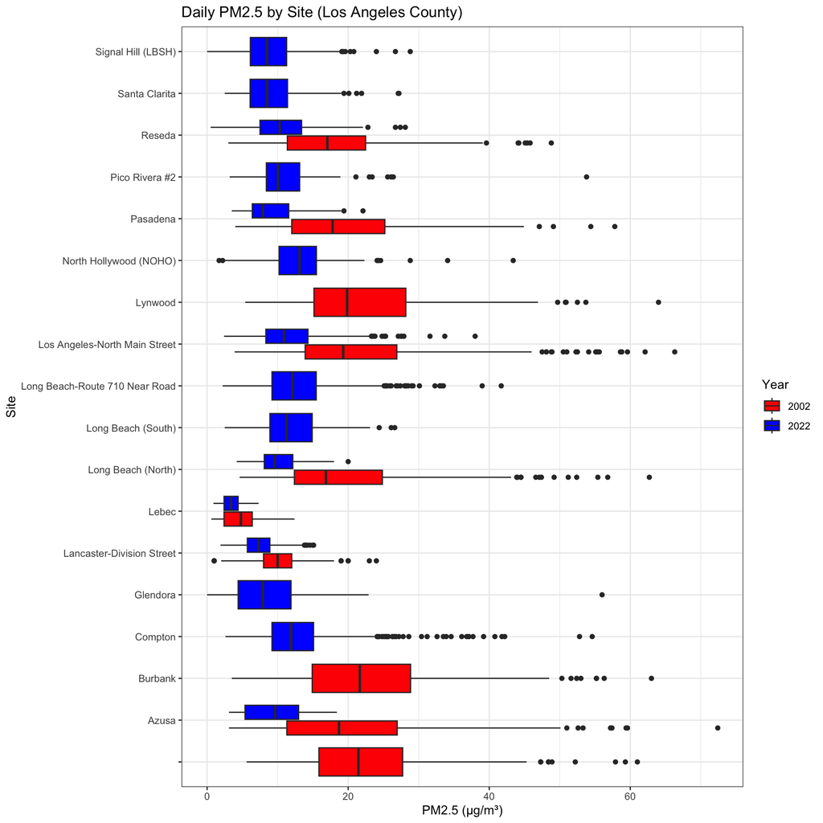

```r
#Visual distribution
library(ggplot2)

# A) Boxplot
ggplot(la_sites, aes(x = site, y = pm, fill = factor(year))) +
  geom_boxplot() +
  coord_flip() +
  scale_fill_manual(values = c("2002" = "red", "2022" = "blue")) +
  labs(title = "Daily PM2.5 by Site (Los Angeles County)",
       x = "Site", y = "PM2.5 (µg/m³)", fill = "Year") +
  theme_bw()
```

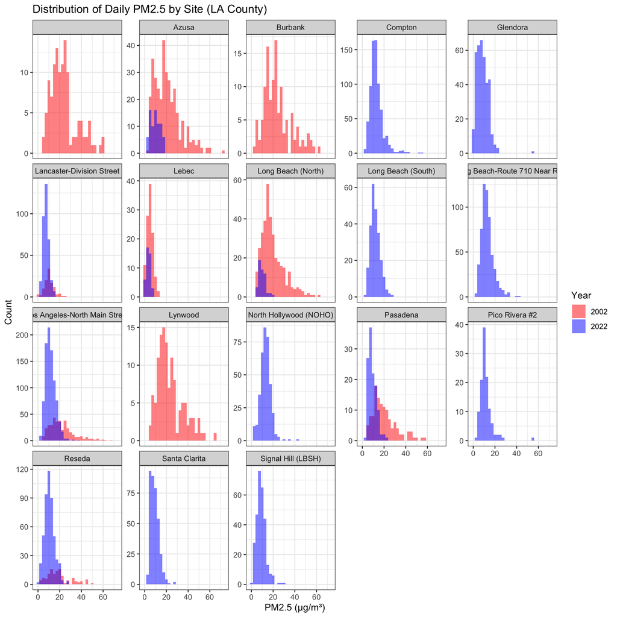

```r
# B) Histogram per site (2002 vs 2022)
ggplot(la_sites, aes(x = pm, fill = factor(year))) +
  geom_histogram(position = "identity", alpha = 0.5, bins = 30) +
  facet_wrap(~ site, scales = "free_y") +
  scale_fill_manual(values = c("2002" = "red", "2022" = "blue")) +
  labs(title = "Distribution of Daily PM2.5 by Site (LA County)",
       x = "PM2.5 (µg/m³)", y = "Count", fill = "Year") +
  theme_bw()
```

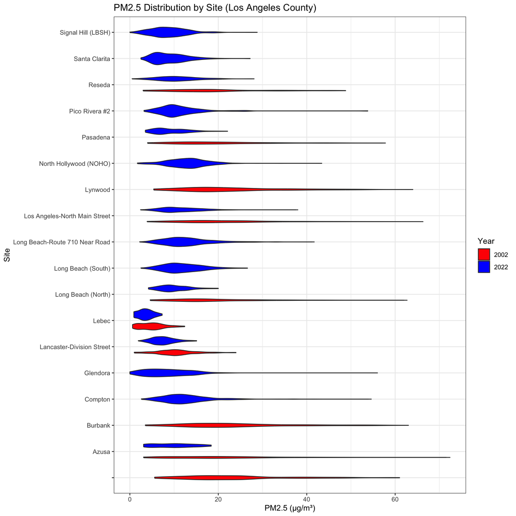

```r
# C) Violin plot
ggplot(la_sites, aes(x = site, y = pm, fill = factor(year))) +
  geom_violin(position = "dodge") +
  coord_flip() +
  scale_fill_manual(values = c("2002" = "red", "2022" = "blue")) +
  labs(title = "PM2.5 Distribution by Site (Los Angeles County)",
       x = "Site", y = "PM2.5 (µg/m³)", fill = "Year") +
  theme_bw()
```

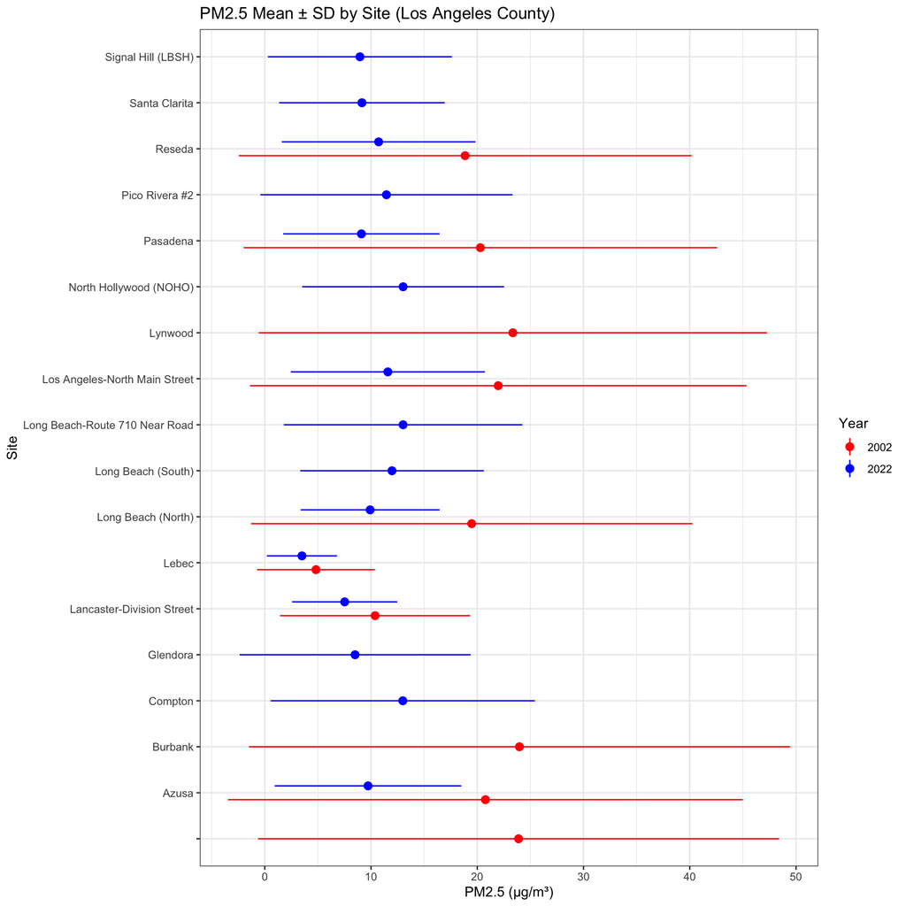

```r
# D) Mean ± SD per site (statistical summary graph by year)
ggplot(la_sites, aes(x = site, y = pm, color = factor(year))) +
  stat_summary(fun.data = "mean_sdl", geom = "pointrange",
               position = position_dodge(width = 0.6)) +
  coord_flip() +
  scale_color_manual(values = c("2002" = "red", "2022" = "blue")) +
  labs(title = "PM2.5 Mean ± SD by Site (Los Angeles County)",
       x = "Site", y = "PM2.5 (µg/m³)", color = "Year") +
  theme_bw()
```

**Explanation-**

The medians also declined. Boxplots and violin plots indicate that in 2002, many sites had higher medians, wide spreads, whereas in 2022 the distributions were compressed with lower medians.

Overall, the Los Angeles site-level analysis mirrors the county and statewide results: air quality has improved significantly over time. Nonetheless, site-to-site differences persist, maybe due to local emission sources and neighborhood-level environmental conditions.